# CaseStudy2

EMP

11/28/2021

## Description:

DDSAnalytics is an analytics company that specializes in talent management solutions for Fortune 100 companies. Talent management is defined as the iterative process of developing and retaining employees. It may include workforce planning, employee training programs, identifying high-potential employees and reducing/preventing voluntary employee turnover (attrition). To gain a competitive edge over its competition, DDSAnalytics is planning to leverage data science for talent management. The executive leadership has identified predicting employee turnover as its first application of data science for talent management. Before the business green lights the project, they have tasked your data science team to conduct an analysis of existing employee data.

```r
library(tidyverse)
```

```r
library(readxl)
library(corrplot)
library(caret)
library(scales)
library(plotly)
library(fastDummies)
library(ggpubr)
library(cowplot)
library(ggthemes)
library(skimr)
library(reshape2)
library(DataExplorer)
library(inspectdf)
library(ggplot2)
library(dplyr)
library(knitr)
```

```r
data <- data.frame(read.csv("C:\\Users\\erinm\\Documents\\GitHub\\MSDS_6306_Doing-Data-Science\\Unit 14 and 15 Case Study 2\\CaseStudy2-data.csv", header = TRUE))
```

There appear to be unnecessary columns, such as ID, EmployeeCount, EmployeeNumber, Over18, and StandardHours. Since these columns will not be used for the analysis they are removed for further EDA. Change character columns into factors

```r
data2 <- select(data, -c("ID", "EmployeeNumber", "EmployeeCount", "Over18", "StandardHours"))

data2$StockOptionLevel= as.factor(data2$StockOptionLevel)
data2$JobSatisfaction= as.factor(data2$JobSatisfaction)
#Check for missing values in datasets (answer was FALSE for each one)

glimpse(data2)
```

```
## Rows: 870
## Columns: 31
## $ Age                      <int> 32, 40, 35, 32, 24, 27, 41, 37, 34, 34, 43, 2~
## $ Attrition                <chr> "No", "No", "No", "No", "No", "No", "No", "No~
## $ BusinessTravel           <chr> "Travel_Rarely", "Travel_Rarely", "Travel_Fre~
## $ DailyRate                <int> 117, 1308, 200, 801, 567, 294, 1283, 309, 133~
## $ Department               <chr> "Sales", "Research & Development", "Research ~
## $ DistanceFromHome         <int> 13, 14, 18, 1, 2, 10, 5, 10, 10, 10, 6, 1, 7,~
## $ Education                <int> 4, 3, 2, 4, 1, 2, 5, 4, 4, 4, 3, 2, 3, 1, 2, ~
## $ EducationField           <chr> "Life Sciences", "Medical", "Life Sciences", ~
## $ EnvironmentSatisfaction  <int> 2, 3, 3, 3, 1, 4, 2, 4, 3, 4, 1, 3, 3, 3, 4, ~
## $ Gender                   <chr> "Male", "Male", "Male", "Female", "Female", "~
## $ HourlyRate               <int> 73, 44, 60, 48, 32, 32, 90, 88, 87, 92, 81, 4~
## $ JobInvolvement           <int> 3, 2, 3, 3, 3, 3, 4, 2, 3, 2, 2, 3, 3, 3, 3, ~
## $ JobLevel                 <int> 2, 5, 3, 3, 1, 3, 1, 2, 1, 2, 5, 1, 3, 1, 1, ~
```

[output cut: 18 more lines]

```r
anyNA(data2)
```

```
## [1] FALSE
```

```r
data_cat = inspect_cat(data2)
data_cat$levels
```

```
## $Attrition
## # A tibble: 2 x 3
##   value  prop   cnt
##   <chr> <dbl> <int>
## 1 No    0.839   730
## 2 Yes   0.161   140
##
## $BusinessTravel
## # A tibble: 3 x 3
##   value              prop   cnt
##   <chr>             <dbl> <int>
## 1 Travel_Rarely     0.710   618
## 2 Travel_Frequently 0.182   158
## 3 Non-Travel        0.108    94
##
## $Department
## # A tibble: 3 x 3
##   value                    prop   cnt
##   <chr>                   <dbl> <int>
## 1 Research & Development 0.646    562
## 2 Sales                  0.314    273
## 3 Human Resources        0.0402    35
##
## $EducationField
## # A tibble: 6 x 3
##   value              prop   cnt
##   <chr>             <dbl> <int>
## 1 Life Sciences    0.411    358
## 2 Medical          0.310    270
## 3 Marketing        0.115    100
## 4 Technical Degree 0.0862    75
## 5 Other            0.0598    52
## 6 Human Resources  0.0172    15
##
## $Gender
## # A tibble: 2 x 3
##   value   prop   cnt
##   <chr>  <dbl> <int>
## 1 Male   0.593   516
## 2 Female 0.407   354
```

[output cut: 32 more lines]

```
## $OverTime
## # A tibble: 2 x 3
##   value  prop   cnt
##   <chr> <dbl> <int>
## 1 No    0.710   618
## 2 Yes   0.290   252
##
## $StockOptionLevel
## # A tibble: 4 x 3
##   value   prop   cnt
##   <chr>  <dbl> <int>
## 1 0     0.436    379
## 2 1     0.408    355
## 3 2     0.0931    81
## 4 3     0.0632    55
```

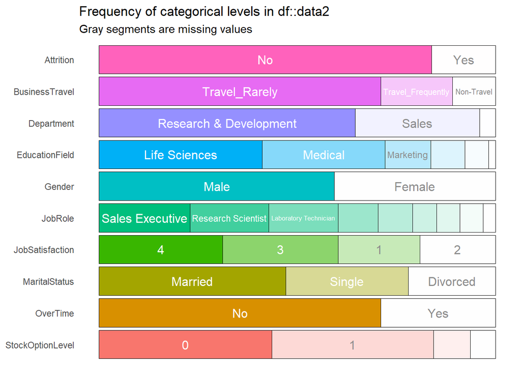

```r
show_plot(data_cat)
```

[figure not shown]

```r
data_cor <- select_if(data2, is.numeric) %>% cor()
corrplot(data_cor, method = "number", type = "upper", tl.col = "black", tl.cex = 1, tl.srt = 80)
```

```r
data_cor %>% names -> cont
data_cor %>% keep(is.numeric) %>% names -> cont
cont
```

A series of correlation tests are created to look for relationships between incomes and rates. No evidence of a correlation was found for any of the rates or incomes.

```r
cor.test(data$MonthlyRate, data$HourlyRate)
```

```
##
##  Pearson's product-moment correlation
##
## data:  data$MonthlyRate and data$HourlyRate
## t = -0.47249, df = 868, p-value = 0.6367
## alternative hypothesis: true correlation is not equal to 0
## 95 percent confidence interval:
##  -0.08241306  0.05048437
## sample estimates:
##         cor
## -0.01603517
```

```r
cor.test(data$MonthlyIncome, data$HourlyRate)
```

```
##
##  Pearson's product-moment correlation
##
## data:  data$MonthlyIncome and data$HourlyRate
## t = 0.070448, df = 868, p-value = 0.9439
## alternative hypothesis: true correlation is not equal to 0
## 95 percent confidence interval:
##  -0.06408477  0.06884594
## sample estimates:
##         cor
## 0.002391151
```

```r
cor.test(data$HourlyRate, data$DailyRate)
```

```
##
##  Pearson's product-moment correlation
##
## data:  data$HourlyRate and data$DailyRate
## t = 1.4305, df = 868, p-value = 0.1529
## alternative hypothesis: true correlation is not equal to 0
## 95 percent confidence interval:
##  -0.01802787  0.11459234
## sample estimates:
##        cor
## 0.04849597
```

```r
cor.test(data$MonthlyIncome, data$MonthlyRate)
```

```
##
##  Pearson's product-moment correlation
##
## data:  data$MonthlyIncome and data$MonthlyRate
## t = 1.907, df = 868, p-value = 0.05684
## alternative hypothesis: true correlation is not equal to 0
## 95 percent confidence interval:
##  -0.001879735  0.130499526
## sample estimates:
##        cor
## 0.06459407
```

```r
cor.test(data$DailyRate, data$MonthlyIncome)
```

```
##
##  Pearson's product-moment correlation
##
## data:  data$DailyRate and data$MonthlyIncome
## t = 0.0025898, df = 868, p-value = 0.9979
## alternative hypothesis: true correlation is not equal to 0
## 95 percent confidence interval:
##  -0.06637822  0.06655325
## sample estimates:
##          cor
## 8.790339e-05
```

```r
cor.test(data$DailyRate, data$MonthlyRate)
```

```
##
##  Pearson's product-moment correlation
##
## data:  data$DailyRate and data$MonthlyRate
## t = -0.81466, df = 868, p-value = 0.4155
## alternative hypothesis: true correlation is not equal to 0
## 95 percent confidence interval:
##  -0.09393393  0.03889642
## sample estimates:
##         cor
## -0.02764077
```

Look for correlations between income and rates vs attrition and we see that there is a correlation between monthly income and attrition

Since no daily rate, hourly rate, and monthly rate were not significant we will not use them for future analysis of attrition contributors.

```r
data2$Attrition[data2$Attrition=="Yes"]=1
data2$Attrition[data2$Attrition=="No"]=0
data2$Attrition=as.numeric(data2$Attrition)

class(data2$Attrition)
```

```
## [1] "numeric"
```

```r
cor.test(data2$MonthlyIncome, data2$Attrition)
```

```
##
##  Pearson's product-moment correlation
##
## data:  data2$MonthlyIncome and data2$Attrition
## t = -4.6199, df = 868, p-value = 4.422e-06
## alternative hypothesis: true correlation is not equal to 0
## 95 percent confidence interval:
##  -0.21912446 -0.08936942
## sample estimates:
##       cor
## -0.154915
```

```r
cor.test(data2$MonthlyRate, data2$Attrition)
```

```
##
##  Pearson's product-moment correlation
##
## data:  data2$MonthlyRate and data2$Attrition
## t = -1.2749, df = 868, p-value = 0.2027
## alternative hypothesis: true correlation is not equal to 0
## 95 percent confidence interval:
##  -0.10938360  0.02330051
## sample estimates:
##         cor
## -0.04323217
```

```r
cor.test(data2$HourlyRate, data2$Attrition)
```

```
##
##  Pearson's product-moment correlation
##
## data:  data2$HourlyRate and data2$Attrition
## t = 1.0777, df = 868, p-value = 0.2815
## alternative hypothesis: true correlation is not equal to 0
## 95 percent confidence interval:
##  -0.0299844  0.1027702
## sample estimates:
##        cor
## 0.03655418
```

```r
cor.test(data2$DailyRate, data2$Attrition)
```

```
##
##  Pearson's product-moment correlation
##
## data:  data2$DailyRate and data2$Attrition
## t = -0.99618, df = 868, p-value = 0.3194
## alternative hypothesis: true correlation is not equal to 0
## 95 percent confidence interval:
##  -0.10003417  0.03274616
## sample estimates:
##         cor
## -0.03379312
```

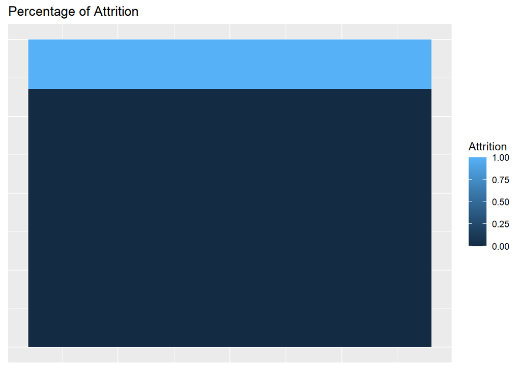

```r
percent <- data2 %>% group_by(Attrition) %>% summarize(count=n(), quit = n()/nrow(data2))

percent %>% ggplot(aes(x=2, y=quit, fill=Attrition)) + geom_col() + ggtitle("Percentage of Attrition") + theme(axis.title = element_blank(), axis.ticks = element_blank(), axis.text = element_blank())
```

```r
count(data2, Attrition)
```

```
##   Attrition   n
## 1         0 730
## 2         1 140
```

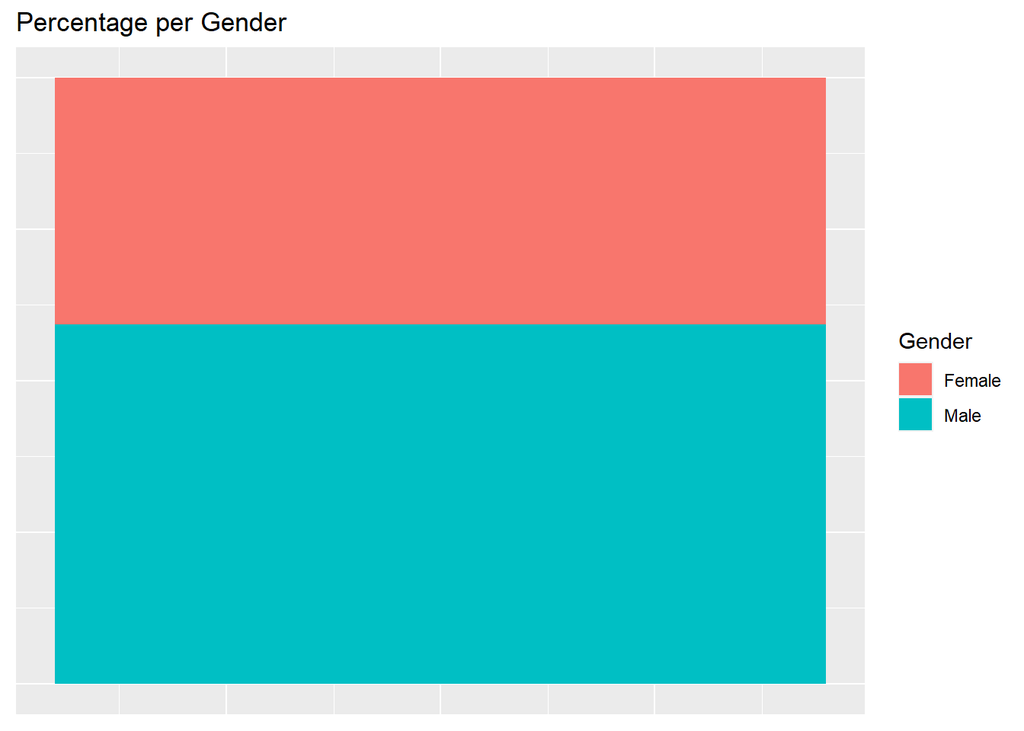

```r
genderpercent <- data2 %>% group_by(Gender) %>% summarize(count=n(), GendPerc = n()/nrow(data2))

genderpercent %>% ggplot(aes(x=2, y=GendPerc, fill=Gender)) + geom_col() + ggtitle("Percentage per Gender") + theme(axis.title = element_blank(), axis.ticks = element_blank(), axis.text = element_blank())
```

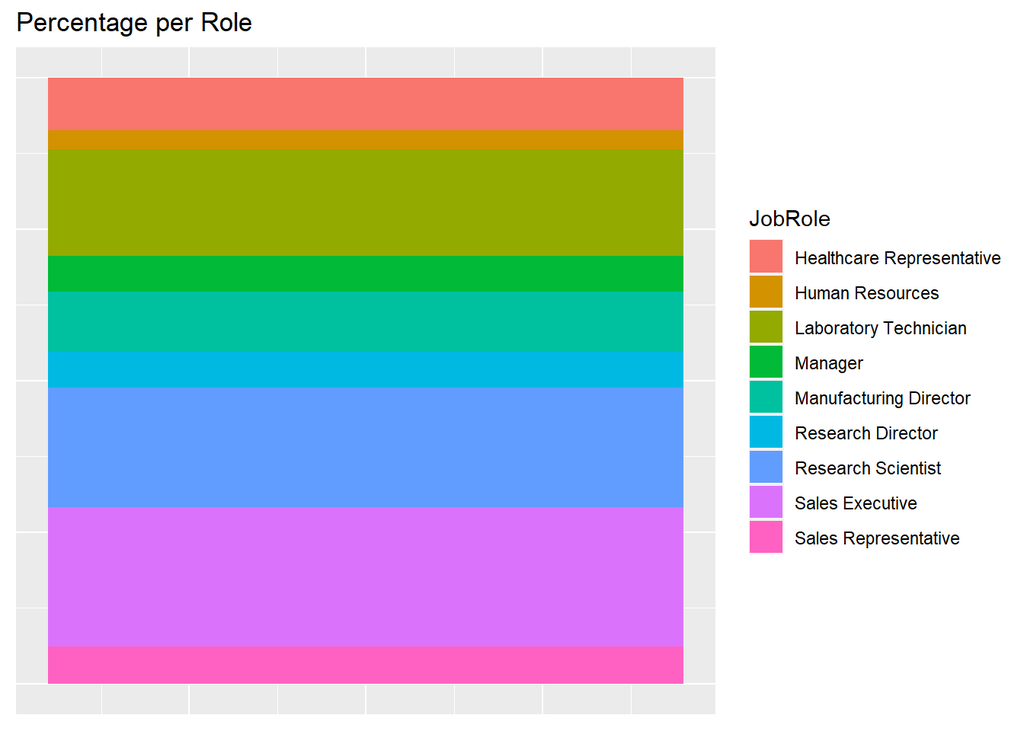

```r
JobRole_perc <- data2 %>% group_by(JobRole) %>% summarize(count=n(), RolePercentage = n()/nrow(data2))

JobRole_perc %>% ggplot(aes(x=2, y=RolePercentage, fill=JobRole)) + geom_col() + ggtitle("Percentage per Role") + theme(axis.title = element_blank(), axis.ticks = element_blank(), axis.text = element_blank())
```

[figure not shown]

```r
categplot <- function(df, x,y){ggplot(data = df, aes_string(x=x, fill = y)) + geom_bar(position="fill", alpha = 0.9) + coord_flip()}

catvar1 <- data2 %>% select_if(is.factor) %>% names()
catvar1 <- catvar1[-1]
cat_plot <- lapply(catvar1, function(x) categplot(data2,x,"Attrition"))
cowplot::plot_grid(plotlist = cat_plot)
```

Create a new dataset so original is safe in case things go wrong.

Browsing through the VIF data shows that Department and Job Role have values greater than 5, so these are removed from future analysis

```r
data_m1 = data2
monthly_Inc <- lm(MonthlyIncome~., data = data_m1)
summary(monthly_Inc)
```

```
##
## Call:
## lm(formula = MonthlyIncome ~ ., data = data_m1)
##
## Residuals:
##     Min      1Q  Median      3Q     Max
## -3660.4  -673.3   -19.5   628.8  4136.3
##
## Coefficients:
##                                    Estimate Std. Error t value Pr(>|t|)
## (Intercept)                       6.291e+01  7.815e+02   0.080 0.935862
## Age                              -1.189e+00  5.667e+00  -0.210 0.833805
## Attrition                         9.737e+01  1.173e+02   0.830 0.406697
## BusinessTravelTravel_Frequently   1.932e+02  1.425e+02   1.356 0.175612
## BusinessTravelTravel_Rarely       3.752e+02  1.204e+02   3.115 0.001901 **
## DailyRate                         1.459e-01  9.179e-02   1.589 0.112348
## DepartmentResearch & Development  1.128e+02  4.789e+02   0.236 0.813860
## DepartmentSales                  -4.413e+02  4.892e+02  -0.902 0.367225
## DistanceFromHome                 -6.472e+00  4.593e+00  -1.409 0.159191
## Education                        -3.413e+01  3.731e+01  -0.915 0.360608
## EducationFieldLife Sciences       1.353e+02  3.699e+02   0.366 0.714535
## EducationFieldMarketing           1.204e+02  3.920e+02   0.307 0.758880
## EducationFieldMedical             3.414e+01  3.708e+02   0.092 0.926677
## EducationFieldOther               8.750e+01  3.958e+02   0.221 0.825070
## EducationFieldTechnical Degree    9.092e+01  3.854e+02   0.236 0.813535
## EnvironmentSatisfaction          -6.864e+00  3.376e+01  -0.203 0.838954
## GenderMale                        1.118e+02  7.473e+01   1.497 0.134854
## HourlyRate                       -2.070e-01  1.837e+00  -0.113 0.910327
## JobInvolvement                    2.074e+01  5.341e+01   0.388 0.697887
## JobLevel                          2.790e+03  8.377e+01  33.306  < 2e-16 ***
## JobRoleHuman Resources           -1.890e+02  5.173e+02  -0.365 0.714874
## JobRoleLaboratory Technician     -5.983e+02  1.720e+02  -3.478 0.000531 ***
## JobRoleManager                    4.269e+03  2.840e+02  15.034  < 2e-16 ***
## JobRoleManufacturing Director     1.968e+02  1.708e+02   1.152 0.249780
## JobRoleResearch Director          4.078e+03  2.200e+02  18.532  < 2e-16 ***
## JobRoleResearch Scientist        -3.411e+02  1.711e+02  -1.994 0.046487 *
## JobRoleSales Executive            5.068e+02  3.594e+02   1.410 0.158833
## JobRoleSales Representative       6.316e+01  3.929e+02   0.161 0.872319
## JobSatisfaction2                 -6.197e+01  1.166e+02  -0.531 0.595269
## JobSatisfaction3                 -3.022e+01  1.056e+02  -0.286 0.774912
```

[output cut: 10 more lines]

```
## StockOptionLevel2                -2.660e+01  1.658e+02  -0.160 0.872578
## StockOptionLevel3                 7.029e+01  1.878e+02   0.374 0.708319
## TotalWorkingYears                 5.047e+01  1.103e+01   4.574 5.53e-06 ***
## TrainingTimesLastYear             2.383e+01  2.925e+01   0.815 0.415370
## WorkLifeBalance                  -3.265e+01  5.191e+01  -0.629 0.529583
## YearsAtCompany                   -5.316e+00  1.367e+01  -0.389 0.697540
## YearsInCurrentRole                4.939e+00  1.706e+01   0.289 0.772291
## YearsSinceLastPromotion           3.158e+01  1.537e+01   2.054 0.040299 *
## YearsWithCurrManager             -2.509e+01  1.674e+01  -1.499 0.134250
## ---
## Signif. codes:  0 '***' 0.001 '**' 0.01 '*' 0.05 '.' 0.1 ' ' 1
##
## Residual standard error: 1058 on 821 degrees of freedom
## Multiple R-squared:   0.95,  Adjusted R-squared:  0.947
## F-statistic: 324.8 on 48 and 821 DF,  p-value: < 2.2e-16
```

```r
car::vif(monthly_Inc)
```

```
##                                GVIF Df GVIF^(1/(2*Df))
## Age                        1.986347  1        1.409378
## Attrition                  1.443678  1        1.201532
## BusinessTravel             1.131337  2        1.031331
## DailyRate                  1.052192  1        1.025764
## Department               112.486683  2        3.256681
## DistanceFromHome           1.084243  1        1.041270
## Education                  1.131072  1        1.063519
## EducationField             3.038861  5        1.117561
## EnvironmentSatisfaction    1.069546  1        1.034188
## Gender                     1.047250  1        1.023352
## HourlyRate                 1.061188  1        1.030140
## JobInvolvement             1.096515  1        1.047146
## JobLevel                   6.473360  1        2.544280
## JobRole                  556.775464  8        1.484585
## JobSatisfaction            1.188253  3        1.029165
## MaritalStatus              3.083481  2        1.325136
## MonthlyRate                1.043451  1        1.021494
## NumCompaniesWorked         1.417955  1        1.190779
## OverTime                   1.149190  1        1.072003
## PercentSalaryHike          2.643203  1        1.625793
## PerformanceRating          2.633248  1        1.622729
## RelationshipSatisfaction   1.050736  1        1.025054
## StockOptionLevel           3.250006  3        1.217066
## TotalWorkingYears          5.335613  1        2.309895
## TrainingTimesLastYear      1.075449  1        1.037038
## WorkLifeBalance            1.060473  1        1.029793
## YearsAtCompany             5.260709  1        2.293624
## YearsInCurrentRole         2.992868  1        1.729991
## YearsSinceLastPromotion    1.862397  1        1.364697
## YearsWithCurrManager       2.779073  1        1.667055
```

Removing more unnecessary columns: Department, Job Role, Years At Company; and remember that we have yet to remove the useless Hourly Rate, Daily Rate, and Monthly Rate columns

```r
data3 <- select(data2, -c("Department", "JobRole", "YearsAtCompany", "HourlyRate", "DailyRate", "MonthlyRate"))
```

Now we see that we have no columns with a VIF value greater than 5, and a few columns with p-values < 0.05: Business Travel-Travel_Rarely, Distance From Home, Job Level, Total Working Years, Years With Curr Manager. The RMSE is $1337.75, and the adjusted R2 is 0.911 which infers that ~91% of Monthly Income can be predicted by this model.

```r
data3_lm <- lm(MonthlyIncome ~., data = data3)
summary(data3_lm)
```

```
##
## Call:
## lm(formula = MonthlyIncome ~ ., data = data3)
##
## Residuals:
##     Min      1Q  Median      3Q     Max
## -5869.8  -787.8    -4.4   729.1  4321.1
##
## Coefficients:
##                                  Estimate Std. Error t value Pr(>|t|)
## (Intercept)                     -1335.754    774.589  -1.724  0.08499 .
## Age                                -1.897      7.266  -0.261  0.79408
## Attrition                         104.154    149.050   0.699  0.48488
## BusinessTravelTravel_Frequently    14.383    182.668   0.079  0.93726
## BusinessTravelTravel_Rarely       321.312    154.786   2.076  0.03821 *
## DistanceFromHome                  -15.857      5.900  -2.688  0.00734 **
## Education                          14.196     47.843   0.297  0.76675
## EducationFieldLife Sciences      -287.754    367.049  -0.784  0.43328
## EducationFieldMarketing          -650.298    385.471  -1.687  0.09197 .
## EducationFieldMedical            -250.319    369.502  -0.677  0.49831
## EducationFieldOther              -357.770    407.082  -0.879  0.37973
## EducationFieldTechnical Degree   -289.954    392.880  -0.738  0.46071
## EnvironmentSatisfaction           -64.113     43.257  -1.482  0.13867
## GenderMale                         71.979     96.339   0.747  0.45519
## JobInvolvement                    105.087     68.284   1.539  0.12419
## JobLevel                         3750.931     70.148  53.472  < 2e-16 ***
## JobSatisfaction2                  -57.575    149.079  -0.386  0.69944
## JobSatisfaction3                  -72.816    135.917  -0.536  0.59228
## JobSatisfaction4                   -6.485    135.465  -0.048  0.96183
## MaritalStatusMarried              155.245    129.623   1.198  0.23139
## MaritalStatusSingle                28.654    201.964   0.142  0.88721
## NumCompaniesWorked                 -9.631     21.077  -0.457  0.64785
## OverTimeYes                        -4.138    108.783  -0.038  0.96967
## PercentSalaryHike                  30.632     20.365   1.504  0.13292
## PerformanceRating                -288.093    207.465  -1.389  0.16531
## RelationshipSatisfaction           27.185     43.119   0.630  0.52857
## StockOptionLevel1                  66.216    158.437   0.418  0.67611
## StockOptionLevel2                 -35.444    212.537  -0.167  0.86760
## StockOptionLevel3                   7.409    241.592   0.031  0.97554
## TotalWorkingYears                  68.011     13.292   5.117 3.86e-07 ***
## TrainingTimesLastYear              20.415     37.427   0.545  0.58557
## WorkLifeBalance                   -18.742     66.845  -0.280  0.77926
## YearsInCurrentRole                -16.339     19.951  -0.819  0.41304
## YearsSinceLastPromotion             2.412     18.908   0.128  0.89851
## YearsWithCurrManager              -48.630     19.565  -2.486  0.01313 *
## ---
## Signif. codes:  0 '***' 0.001 '**' 0.01 '*' 0.05 '.' 0.1 ' ' 1
##
## Residual standard error: 1372 on 835 degrees of freedom
## Multiple R-squared:  0.9145, Adjusted R-squared:  0.911
## F-statistic: 262.5 on 34 and 835 DF,  p-value: < 2.2e-16
```

```r
car::vif(data3_lm)
```

```
##                              GVIF Df GVIF^(1/(2*Df))
## Age                      1.942249  1        1.393646
## Attrition                1.386727  1        1.177594
## BusinessTravel           1.088508  2        1.021428
## DistanceFromHome         1.064216  1        1.031608
## Education                1.106205  1        1.051763
## EducationField           1.194453  5        1.017928
## EnvironmentSatisfaction  1.044271  1        1.021896
## Gender                   1.035454  1        1.017572
## JobInvolvement           1.065965  1        1.032456
## JobLevel                 2.700152  1        1.643214
## JobSatisfaction          1.118993  3        1.018915
## MaritalStatus            2.951309  2        1.310701
## NumCompaniesWorked       1.303142  1        1.141552
## OverTime                 1.125605  1        1.060945
## PercentSalaryHike        2.587098  1        1.608446
## PerformanceRating        2.560923  1        1.600288
## RelationshipSatisfaction 1.043531  1        1.021534
## StockOptionLevel         3.047865  3        1.204109
## TotalWorkingYears        4.605812  1        2.146116
## TrainingTimesLastYear    1.047655  1        1.023550
## WorkLifeBalance          1.045895  1        1.022690
## YearsInCurrentRole       2.434371  1        1.560247
## YearsSinceLastPromotion  1.675586  1        1.294444
## YearsWithCurrManager     2.258340  1        1.502778
```

```r
trainControl(method = "cv", number = 5) -> TrainCon

MInc_lm <- train(MonthlyIncome ~., data = data3, method = "lmStepAIC", train_Contol = TrainCon)
```

```
## Start:  AIC=12513.34
## .outcome ~ Age + Attrition + BusinessTravelTravel_Frequently +
##     BusinessTravelTravel_Rarely + DistanceFromHome + Education +
##     `EducationFieldLife Sciences` + EducationFieldMarketing +
##     EducationFieldMedical + EducationFieldOther + `EducationFieldTechnical Degree` +
##     EnvironmentSatisfaction + GenderMale + JobInvolvement + JobLevel +
##     JobSatisfaction2 + JobSatisfaction3 + JobSatisfaction4 +
##     MaritalStatusMarried + MaritalStatusSingle + NumCompaniesWorked +
##     OverTimeYes + PercentSalaryHike + PerformanceRating + RelationshipSatisfaction +
##     StockOptionLevel1 + StockOptionLevel2 + StockOptionLevel3 +
##     TotalWorkingYears + TrainingTimesLastYear + WorkLifeBalance +
##     YearsInCurrentRole + YearsSinceLastPromotion + YearsWithCurrManager
##
##                                    Df  Sum of Sq        RSS   AIC
## - PerformanceRating                 1        157 1416112508 12511
## - PercentSalaryHike                 1       2669 1416115020 12511
## - StockOptionLevel3                 1      17669 1416130021 12511
## - MaritalStatusSingle               1      25497 1416137848 12511
## - `EducationFieldTechnical Degree`  1      37154 1416149505 12511
## - `EducationFieldLife Sciences`     1      48260 1416160612 12511
## - StockOptionLevel2                 1      65752 1416178103 12511
## - EducationFieldOther               1     138706 1416251057 12511
## - EducationFieldMarketing           1     259625 1416371977 12512
## - BusinessTravelTravel_Frequently   1     315647 1416427998 12512
## - Age                               1     363531 1416475883 12512
## - EducationFieldMedical             1     460233 1416572584 12512
## - StockOptionLevel1                 1     742330 1416854681 12512
## - NumCompaniesWorked                1    1049658 1417162009 12512
## - WorkLifeBalance                   1    1392265 1417504616 12512
## - OverTimeYes                       1    1438024 1417550375 12512
## - TrainingTimesLastYear             1    1698000 1417810352 12512
## - BusinessTravelTravel_Rarely       1    1776653 1417889005 12512
## - JobSatisfaction4                  1    2601835 1418714186 12513
## <none>                                           1416112351 12513
## - YearsSinceLastPromotion           1    3664148 1419776499 12514
## - MaritalStatusMarried              1    3829085 1419941437 12514
## - JobSatisfaction3                  1    4028372 1420140724 12514
## - GenderMale                        1    4070288 1420182639 12514
## - JobInvolvement                    1    4413642 1420525993 12514
## - RelationshipSatisfaction          1    4739480 1420851832 12514
```

[output cut: 20102 more lines]

```
## .outcome ~ BusinessTravelTravel_Rarely + DistanceFromHome + EducationFieldMarketing +
##     EnvironmentSatisfaction + JobInvolvement + JobLevel + MaritalStatusMarried +
##     TotalWorkingYears + YearsWithCurrManager
##
##                               Df  Sum of Sq        RSS   AIC
## <none>                                      1585015846 12561
## - JobInvolvement               1    3932348 1588948194 12562
## - MaritalStatusMarried         1    3970026 1588985873 12562
## - EnvironmentSatisfaction      1    4979154 1589995000 12562
## - DistanceFromHome             1   12838996 1597854842 12566
## - EducationFieldMarketing      1   12878775 1597894622 12566
## - BusinessTravelTravel_Rarely  1   16737293 1601753139 12568
## - YearsWithCurrManager         1   29408237 1614424083 12575
## - TotalWorkingYears            1   70832125 1655847971 12597
## - JobLevel                     1 5548821138 7133836984 13868
```

```r
summary(MInc_lm)
```

```
##
## Call:
## lm(formula = .outcome ~ BusinessTravelTravel_Rarely + DistanceFromHome +
##     EducationFieldMarketing + EnvironmentSatisfaction + JobInvolvement +
##     JobLevel + MaritalStatusMarried + TotalWorkingYears + YearsWithCurrManager,
##     data = dat)
##
## Residuals:
##     Min      1Q  Median      3Q     Max
## -5857.8  -761.3     0.4   735.0  4244.8
##
## Coefficients:
##                              Estimate Std. Error t value Pr(>|t|)
## (Intercept)                 -1887.027    253.357  -7.448 2.30e-13 ***
## BusinessTravelTravel_Rarely   308.194    102.270   3.014  0.00266 **
## DistanceFromHome              -15.086      5.716  -2.639  0.00846 **
## EducationFieldMarketing      -385.885    145.978  -2.643  0.00836 **
## EnvironmentSatisfaction       -68.977     41.965  -1.644  0.10061
## JobInvolvement                 95.713     65.526   1.461  0.14447
## JobLevel                     3745.203     68.256  54.870  < 2e-16 ***
## MaritalStatusMarried          137.169     93.461   1.468  0.14256
## TotalWorkingYears              64.114     10.342   6.199 8.79e-10 ***
## YearsWithCurrManager          -58.150     14.557  -3.995 7.04e-05 ***
## ---
## Signif. codes:  0 '***' 0.001 '**' 0.01 '*' 0.05 '.' 0.1 ' ' 1
##
## Residual standard error: 1358 on 860 degrees of freedom
## Multiple R-squared:  0.9137, Adjusted R-squared:  0.9128
## F-statistic:  1012 on 9 and 860 DF,  p-value: < 2.2e-16
```

K-Nearest Neighbor attrition analysis: create training and test set from the data

```r
data3$StockOptionLevel = as.factor(data3$StockOptionLevel)
data3$Attrition=as.factor(data3$Attrition)
data4 <- data3
levels(data4$Attrition) <- c("No", "Yes")

Att_whole <- createDataPartition(as.factor(data4$Attrition), p=.8, list = F)
attrition.train <- data4[Att_whole,]
attrition.test <- data4[-Att_whole,]
```

Settings for KNN

```r
train.knn = trainControl(
  method = "repeatedcv",
  number = 5,
  repeats = 25,
  summaryFunction = twoClassSummary,
  classProbs = TRUE)

#KNN for training set
attrition.knn = train(Attrition ~ .,
                       data = attrition.train,
                       method = "knn",
                       metric = "Spec",
                       trControl = train.knn,
                       preProcess = c("center","scale"),
                       tuneLength = 6
)
```

Add predictions to Test dataset

```r
attrition.test$Attrition_KNN = predict(attrition.knn, newdata = attrition.test)

confusionMatrix(table(attrition.test$Attrition_KNN, attrition.test$Attrition_KNN))
```

```
## Confusion Matrix and Statistics
##
##
##        No Yes
##   No  165   0
##   Yes   0   9
##
##                Accuracy : 1
##                  95% CI : (0.979, 1)
##     No Information Rate : 0.9483
##     P-Value [Acc > NIR] : 9.697e-05
##
##                   Kappa : 1
##
##  Mcnemar's Test P-Value : NA
##
##             Sensitivity : 1.0000
##             Specificity : 1.0000
##          Pos Pred Value : 1.0000
##          Neg Pred Value : 1.0000
##              Prevalence : 0.9483
##          Detection Rate : 0.9483
##    Detection Prevalence : 0.9483
##       Balanced Accuracy : 1.0000
##
##        'Positive' Class : No
##
```

Add predictions to Train dataset

```r
attrition.train$Attrition_KNN <- predict(attrition.knn, newdata = attrition.train)

confusionMatrix(table(attrition.train$Attrition, attrition.train$Attrition_KNN))
```

```
## Confusion Matrix and Statistics
##
##
##        No Yes
##   No  578   6
##   Yes  82  30
##
##                Accuracy : 0.8736
##                  95% CI : (0.8466, 0.8973)
##     No Information Rate : 0.9483
##     P-Value [Acc > NIR] : 1
##
##                   Kappa : 0.3549
##
##  Mcnemar's Test P-Value : 1.295e-15
##
##             Sensitivity : 0.8758
##             Specificity : 0.8333
##          Pos Pred Value : 0.9897
##          Neg Pred Value : 0.2679
##              Prevalence : 0.9483
##          Detection Rate : 0.8305
##    Detection Prevalence : 0.8391
##       Balanced Accuracy : 0.8545
##
##        'Positive' Class : No
##
```

Entire dataset/final model

```r
predict(attrition.knn, newdata = data4) -> data4$Attrition_KNN
confusionMatrix(table(data4$Attrition, data4$Attrition_KNN))
```

```
## Confusion Matrix and Statistics
##
##
##        No Yes
##   No  723   7
##   Yes 102  38
##
##                Accuracy : 0.8747
##                  95% CI : (0.8509, 0.896)
##     No Information Rate : 0.9483
##     P-Value [Acc > NIR] : 1
##
##                   Kappa : 0.3608
##
##  Mcnemar's Test P-Value : <2e-16
##
##             Sensitivity : 0.8764
##             Specificity : 0.8444
##          Pos Pred Value : 0.9904
##          Neg Pred Value : 0.2714
##              Prevalence : 0.9483
##          Detection Rate : 0.8310
##    Detection Prevalence : 0.8391
##       Balanced Accuracy : 0.8604
##
##        'Positive' Class : No
##
```

Attrition prediction

```r
data4$Attrition_KNN <- predict(attrition.knn, newdata = data4)
confusionMatrix(table(data4$Attrition, data4$Attrition_KNN))
```

```
## Confusion Matrix and Statistics
##
##
##        No Yes
##   No  723   7
##   Yes 102  38
##
##                Accuracy : 0.8747
##                  95% CI : (0.8509, 0.896)
##     No Information Rate : 0.9483
##     P-Value [Acc > NIR] : 1
##
##                   Kappa : 0.3608
##
##  Mcnemar's Test P-Value : <2e-16
##
##             Sensitivity : 0.8764
##             Specificity : 0.8444
##          Pos Pred Value : 0.9904
##          Neg Pred Value : 0.2714
##              Prevalence : 0.9483
##          Detection Rate : 0.8310
##    Detection Prevalence : 0.8391
##       Balanced Accuracy : 0.8604
##
##        'Positive' Class : No
##
```

Predictions based on “CaseStudy2CompSet No Attrition” dataset

```r
attrition_pred <- read.csv("C:\\Users\\erinm\\Documents\\GitHub\\MSDS_6306_Doing-Data-Science\\Unit 14 and 15 Case Study 2\\CaseStudy2CompSet No Attrition.csv", sep = ",",
                           header = TRUE)

str(attrition_pred)
```

```
## 'data.frame':    300 obs. of  35 variables:
##  $ ID                      : int  1171 1172 1173 1174 1175 1176 1177 1178 1179 1180 ...
##  $ Age                     : int  35 33 26 55 29 51 52 39 31 31 ...
##  $ BusinessTravel          : chr  "Travel_Rarely" "Travel_Rarely" "Travel_Rarely" "Travel_Rarely" ...
##  $ DailyRate               : int  750 147 1330 1311 1246 1456 585 1387 1062 534 ...
##  $ Department              : chr  "Research & Development" "Human Resources" "Research & Development" "Research & Development" ...
##  $ DistanceFromHome        : int  28 2 21 2 19 1 29 10 24 20 ...
##  $ Education               : int  3 3 3 3 3 4 4 5 3 3 ...
##  $ EducationField          : chr  "Life Sciences" "Human Resources" "Medical" "Life Sciences" ...
##  $ EmployeeCount           : int  1 1 1 1 1 1 1 1 1 1 ...
##  $ EmployeeNumber          : int  1596 1207 1107 505 1497 145 2019 1618 1252 587 ...
##  $ EnvironmentSatisfaction : int  2 2 1 3 3 1 1 2 3 1 ...
##  $ Gender                  : chr  "Male" "Male" "Male" "Female" ...
##  $ HourlyRate              : int  46 99 37 97 77 30 40 76 96 66 ...
##  $ JobInvolvement          : int  4 3 3 3 2 2 3 3 2 3 ...
```

[output cut: 21 more lines]

```r
head(attrition_pred)
```

```
##     ID Age    BusinessTravel DailyRate             Department DistanceFromHome
## 1 1171  35     Travel_Rarely       750 Research & Development               28
## 2 1172  33     Travel_Rarely       147        Human Resources                2
## 3 1173  26     Travel_Rarely      1330 Research & Development               21
## 4 1174  55     Travel_Rarely      1311 Research & Development                2
## 5 1175  29     Travel_Rarely      1246                  Sales               19
## 6 1176  51 Travel_Frequently      1456 Research & Development                1
##   Education  EducationField EmployeeCount EmployeeNumber
## 1         3   Life Sciences             1           1596
## 2         3 Human Resources             1           1207
## 3         3         Medical             1           1107
## 4         3   Life Sciences             1            505
## 5         3   Life Sciences             1           1497
## 6         4         Medical             1            145
##   EnvironmentSatisfaction Gender HourlyRate JobInvolvement JobLevel
```

[output cut: 41 more lines]

```r
attrition_pred$StockOptionLevel= as.factor(attrition_pred$StockOptionLevel)

attrition_pred$JobSatisfaction= as.factor(attrition_pred$JobSatisfaction)

attrition_pred$Attrition_KNN <- predict(attrition.knn, newdata = attrition_pred)

confusionMatrix(table(attrition_pred$Attrition, attrition_pred$Attrition_KNN))
```

[output not shown]